# Homework 2

```r
Traveldata <- read.csv("Sept11Travel.csv")
Traveldata
```

```
##         Month Air.RPM..000s.   Rail.PM VMT..billions.
## 1    1/1/1990       35153577 454115779       163.2754
## 2    2/1/1990       32965187 435086002       153.2544
## 3    3/1/1990       39993913 568289732       178.4176
## 4    4/1/1990       37981886 568101697       178.6807
## 5    5/1/1990       38419672 539628385       188.8762
## 6    6/1/1990       42819023 570694457       189.1591
## 7    7/1/1990       45770315 618571581       195.0900
## 8    8/1/1990       48763670 609210368       196.6742
## 9    9/1/1990       38173223 488444939       178.0654
## 10  10/1/1990       39051877 514253920       182.2746
## 11  11/1/1990       35699216 516429873       171.2260
## 12  12/1/1990       37444088 531619395       168.2875
## 13   1/1/1991       34848290 496467387       157.8768
## 14   2/1/1991       29672427 469504489       153.3394
```

[output cut: 158 more lines]

```r
library(forecast)
set.seed(2018)
```

1. Plot the pre-event AIR time series. What time series components appear? #Answer: There is an upward linear trend and seasonality. Solution includes plots for rail and vehicle becauseof question 6. Create a shorter time series(2001, 8)

```r
#pre-event time series for Air
Air.ts <- ts(Traveldata$Air,  start = c(1990, 1), end = c(2001, 8), frequency = 12)
Air.ts
```

```
##           Jan      Feb      Mar      Apr      May      Jun      Jul
## 1990 35153577 32965187 39993913 37981886 38419672 42819023 45770315
## 1991 34848290 29672427 36202993 37146602 38869421 42199760 45384965
## 1992 35265807 33868884 39724539 37294373 39728367 45754460 50807813
## 1993 37911556 34902869 42058882 40814097 42133943 44679864 48622037
## 1994 38863562 36068535 45433842 42418163 44297210 48169096 52410979
## 1995 42050940 38580784 47390145 45427499 45915722 49992583 53345749
## 1996 42734234 43056589 51646570 48063492 49808809 53774378 56576582
## 1997 46692784 43761932 54755166 50182894 51979543 55462027 58771317
## 1998 47290992 44641209 54453961 53044174 54302581 57335447 59441840
## 1999 48861094 46158194 57761057 54968382 55469960 59918608 64397523
## 2000 49745428 49876910 61378569 58981617 61165486 65524091 67883256
## 2001 53129922 49992995 62323049 59801562 60246477 64987625 68573410
##           Aug      Sep      Oct      Nov      Dec
## 1990 48763670 38173223 39051877 35699216 37444088
## 1991 48164550 38481957 39062110 34688141 38575165
## 1992 53219046 41564915 40578092 36863415 39045016
## 1993 50451675 41677832 43264475 38868799 40610043
## 1994 53235052 44677623 45845403 42230318 43868116
## 1995 54776466 45589237 46993036 43703386 45015358
## 1996 58714135 47857913 49873317 44696485 49361193
## 1997 60496856 50076953 51846329 47743798 50414361
## 1998 60813085 49560508 53463147 49561082 51024977
## 1999 63752132 53733696 57407208 53866781 52331272
## 2000 66924512 56441629 58834210 56283261 55380280
## 2001 69003617
```

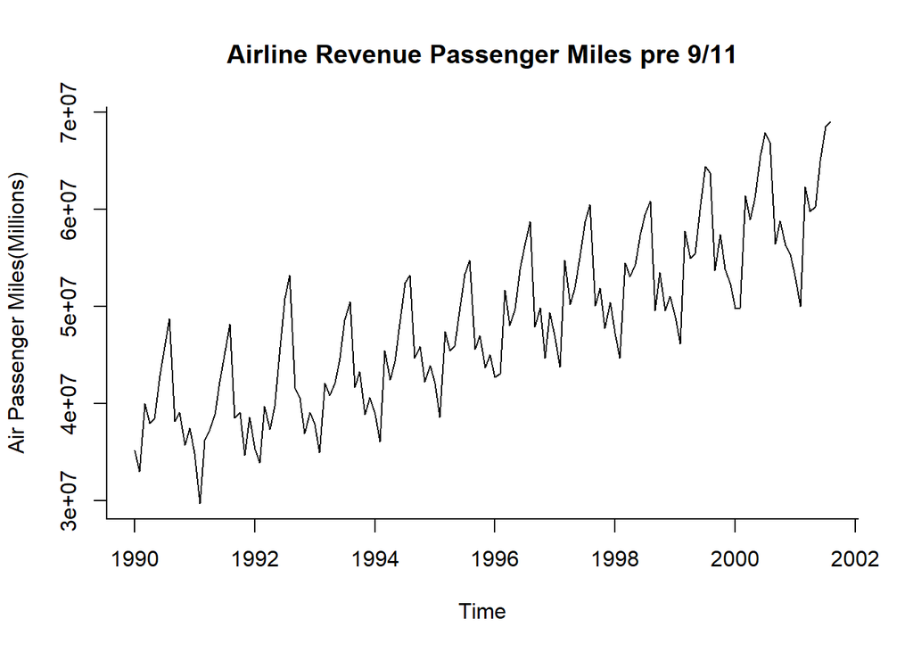

```r
Air.plot <- plot(Air.ts, ylab = "Air Passenger Miles(Millions)", type="l", bty="l",  main = "Airline Revenue Passenger Miles pre 9/11")
```

```r
#pre-event time series for Rail
Rail.ts <- ts(Traveldata$Rail,  start = c(1990, 1), end = c(2001, 8), frequency = 12)
Rail.ts
```

```
##            Jan       Feb       Mar       Apr       May       Jun       Jul
## 1990 454115779 435086002 568289732 568101697 539628385 570694457 618571581
## 1991 496467387 469504489 587905914 509488334 566342448 603845247 633450001
## 1992 493541137 462084011 559205172 572122965 546043825 478204759 610774196
## 1993 500349189 461280157 534476186 562429065 554039017 580500717 586861727
## 1994 472917856 463567851 572167273 546898075 524008197 531971149 578257564
## 1995 425207429 393268412 489360683 490903635 511120586 542693418 571259638
## 1996 362022328 343413949 416042895 425092726 467573082 476554648 525954361
## 1997 337798678 337893100 416925515 408488665 444032624 481053743 540293509
## 1998 371355589 326874247 426172239 447877815 462341914 482325897 537481124
## 1999 384824724 350270063 436837107 435360347 450054655 496553598 543923323
## 2000 366607410 366139276 453096388 473751011 481725263 517102460 564747276
## 2001 379458113 366288212 448912584 455496342 462376555 528690495 564037290
##            Aug       Sep       Oct       Nov       Dec
## 1990 609210368 488444939 514253920 516429873 531619395
## 1991 664013874 494557648 509037626 472359118 550795984
## 1992 627359211 516516158 538313763 539769246 551397116
## 1993 611839976 501353952 507702230 489299178 503041903
## 1994 587229076 490032783 493619903 477594716 490779357
## 1995 580982161 451385426 441202778 435470011 444598571
## 1996 551695523 412344840 425991795 389249720 437256586
## 1997 552486079 425814893 445858326 441249575 454400575
## 1998 526444502 430364874 444719403 427669956 459051399
## 1999 528001216 393137094 425897553 421595015 442742459
## 2000 558060051 446489429 462329685 442268378 461651082
## 2001 562266005
```

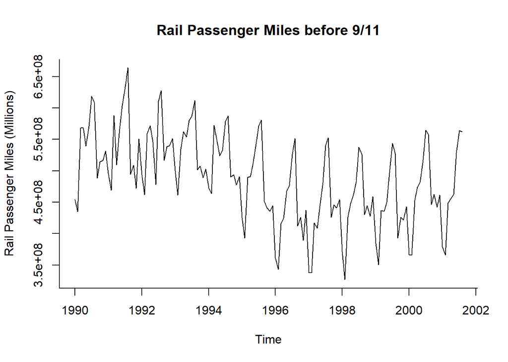

```r
Rail.plot <- plot(Rail.ts, ylab = "Rail Passenger Miles (Millions)", type="l", bty="l", main = "Rail Passenger Miles before 9/11")
```

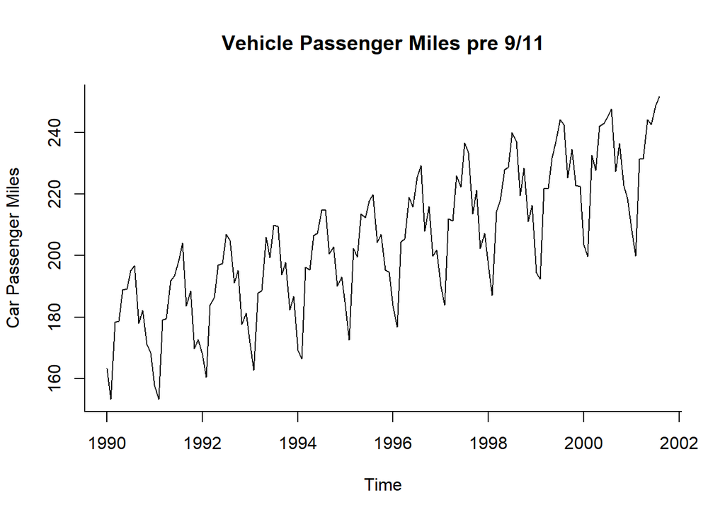

```r
# Pre-event time series for Car
vehicle.ts<- ts(Traveldata$VMT, start = c(1990, 1), end = c(2001,8), frequency = 12)
VMTPlot<- plot(vehicle.ts, ylab = "Car Passenger Miles", type="l", bty="l", main = "Vehicle Passenger Miles pre 9/11")
```

2. The following figure shows a time plot of the seasonally adjusted pre-September-11 AIR series. Which of the following methods would be adequate for forecasting the series shown in the figure? #Answer: Linear Regression Model with trend and seasonality
3. Specify a linear regression model for the AIR series that would produce a seasonally adjusted series similar to the one shown in the figure below, with multiplicative seasonality. What is the outcome variable? What are the predictors? #Answer: Outcome variable: Seasonally adjusted Time # Predictors: Trend and season

```r
# split the data into training and validation
# suppress seasonality using the decompose function

require(xts)
library(scales)
```

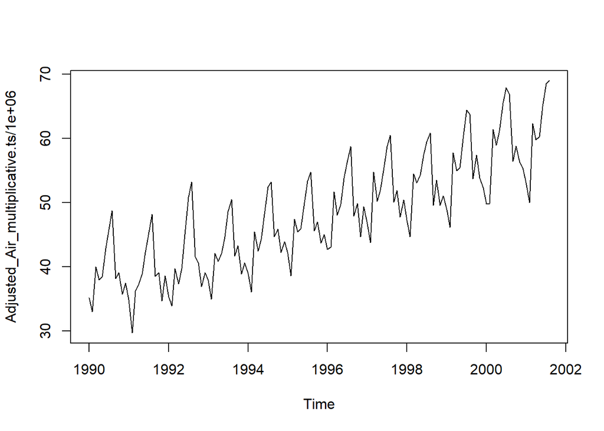

```r
Decompose_AirMultiplicative.ts=decompose(Air.ts,"multiplicative")
Adjusted_Air_multiplicative.ts <- Air.ts-Decompose_AirMultiplicative.ts$seasonal  #With Adjusted seasonality
#PCP <- ts(Adjusted_Air.ts/1000000, start = c(1991,1), end =c(2001,09), frequency = 12)
plot(Adjusted_Air_multiplicative.ts/1000000)
```

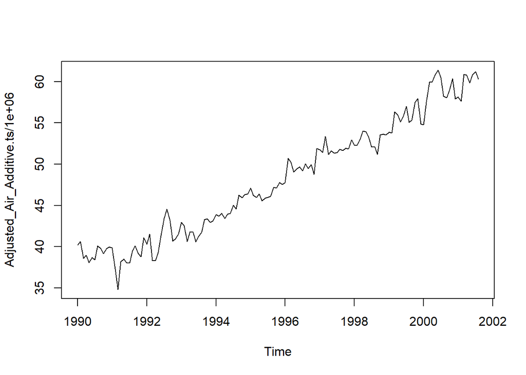

```r
Decompose_Air_Additive.ts=decompose(Air.ts,"additive")
Adjusted_Air_Additive.ts <- Air.ts-Decompose_Air_Additive.ts$seasonal  #With Adjusted seasonality
#PCP <- ts(Adjusted_Air.ts/1000000, start = c(1991,1), end =c(2001,09), frequency = 12)
plot(Adjusted_Air_Additive.ts/1000000)
```

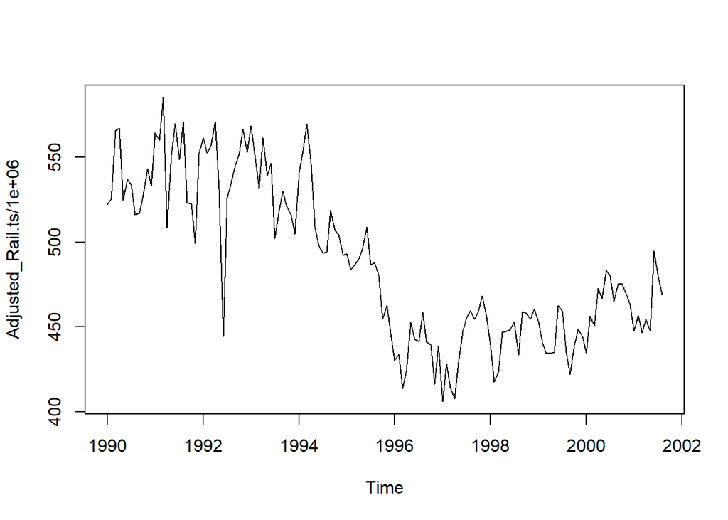

```r
# Using  Decompose function to suppress Seasonality for Rail data
Decompose_Rail.ts=decompose(Rail.ts,"additive")
Adjusted_Rail.ts <- Rail.ts-Decompose_Rail.ts$seasonal  #With Adjusted seasonality
plot(Adjusted_Rail.ts/1000000)
```

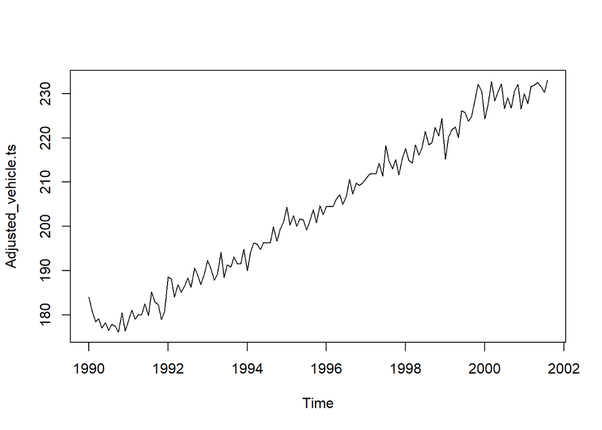

```r
# Using  Decompose function to suppress Seasonality for Vehicle data
Decompose_vehicle.ts=decompose(vehicle.ts,"additive")
Adjusted_vehicle.ts <- vehicle.ts-Decompose_vehicle.ts$seasonal  #With Adjusted seasonality
plot(Adjusted_vehicle.ts)
```

The residual is 1517000

```r
#Adding trend or season or Trend+season
AirMulti.lm <- tslm(Adjusted_Air_multiplicative.ts ~ trend)
summary(AirMulti.lm)
```

```
##
## Call:
## tslm(formula = Adjusted_Air_multiplicative.ts ~ trend)
##
## Residuals:
##      Min       1Q   Median       3Q      Max
## -9466409 -3410590  -681183  3360750 11823514
##
## Coefficients:
##             Estimate Std. Error t value Pr(>|t|)
## (Intercept) 35728434     834749   42.80   <2e-16 ***
## trend         177097      10272   17.24   <2e-16 ***
## ---
## Signif. codes:  0 '***' 0.001 '**' 0.01 '*' 0.05 '.' 0.1 ' ' 1
##
## Residual standard error: 4912000 on 138 degrees of freedom
## Multiple R-squared:  0.6829, Adjusted R-squared:  0.6806
## F-statistic: 297.2 on 1 and 138 DF,  p-value: < 2.2e-16
```

```r
AirMulti.lm.season <- tslm(Adjusted_Air_multiplicative.ts ~ season)
summary(AirMulti.lm.season)
```

```
##
## Call:
## tslm(formula = Adjusted_Air_multiplicative.ts ~ season)
##
## Residuals:
##       Min        1Q    Median        3Q       Max
## -13223898  -6715695   -619517   5563115  12972677
##
## Coefficients:
##             Estimate Std. Error t value Pr(>|t|)
## (Intercept) 42712348    2148157  19.883  < 2e-16 ***
## season2     -2416806    3037953  -0.796  0.42777
## season3      6714542    3037953   2.210  0.02887 *
## season4      4464713    3037953   1.470  0.14411
## season5      5815750    3037953   1.914  0.05781 .
## season6      9839065    3037953   3.239  0.00153 **
## season7     13286466    3037953   4.373 2.51e-05 ***
## season8     14647217    3037953   4.821 3.97e-06 ***
## season9      3454514    3106230   1.112  0.26817
## season10     5125761    3106230   1.650  0.10136
## season11     1306259    3106230   0.421  0.67480
## season12     3021276    3106230   0.973  0.33256
## ---
## Signif. codes:  0 '***' 0.001 '**' 0.01 '*' 0.05 '.' 0.1 ' ' 1
##
## Residual standard error: 7441000 on 128 degrees of freedom
## Multiple R-squared:  0.325,  Adjusted R-squared:  0.267
## F-statistic: 5.603 on 11 and 128 DF,  p-value: 2.716e-07
```

```r
AirMulti.lm.seasonAndTrend <- tslm(Adjusted_Air_multiplicative.ts ~ trend+season)
summary(AirMulti.lm.seasonAndTrend)
```

```
##
## Call:
## tslm(formula = Adjusted_Air_multiplicative.ts ~ trend + season)
##
## Residuals:
##      Min       1Q   Median       3Q      Max
## -3902971 -1002609  -205657   916087  4061887
##
## Coefficients:
##             Estimate Std. Error t value Pr(>|t|)
## (Intercept) 31147495     486733  63.993  < 2e-16 ***
## trend         172610       3175  54.360  < 2e-16 ***
## season2     -2589416     619119  -4.182 5.34e-05 ***
## season3      6369322     619143  10.287  < 2e-16 ***
## season4      3946884     619184   6.374 3.10e-09 ***
## season5      5125311     619241   8.277 1.49e-13 ***
## season6      8976016     619314  14.493  < 2e-16 ***
## season7     12250808     619404  19.778  < 2e-16 ***
## season8     13438949     619509  21.693  < 2e-16 ***
## season9      3109294     633057   4.912 2.73e-06 ***
## season10     4607931     633097   7.278 3.11e-11 ***
## season11      615820     633152   0.973 0.332589
## season12     2158227     633224   3.408 0.000876 ***
## ---
## Signif. codes:  0 '***' 0.001 '**' 0.01 '*' 0.05 '.' 0.1 ' ' 1
##
## Residual standard error: 1517000 on 127 degrees of freedom
## Multiple R-squared:  0.9722, Adjusted R-squared:  0.9696
## F-statistic: 369.9 on 12 and 127 DF,  p-value: < 2.2e-16
```

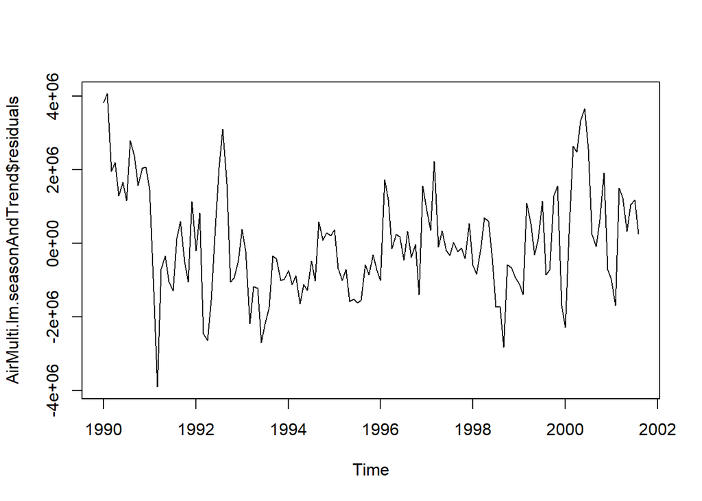

```r
plot(AirMulti.lm.seasonAndTrend$residuals)
```

```r
AirMulti.lm.seasonAndTrend$residuals
```

```
##              Jan         Feb         Mar         Apr         May
## 1990  3833471.31  4061887.23  1959265.65  2197067.40  1283815.90
## 1991  1456867.38 -1302189.71 -3902971.29  -709533.54  -337752.04
## 1992  -196932.56   822950.36 -2452742.22 -2633079.47 -1550122.97
## 1993   377499.51  -214381.58 -2189716.16 -1184672.41 -1215863.91
## 1994  -741811.43 -1120032.51  -886073.10 -1651923.35 -1123913.85
## 1995   374249.63  -679100.45 -1001087.03  -713904.28 -1576718.78
## 1996 -1013773.30  1725387.62  1184021.03  -149228.22   245051.28
## 1997   873459.76   359413.68  2221300.10  -101143.15   344468.35
## 1998  -599649.17  -832626.26  -151221.84   688819.91   596189.41
## 1999 -1100864.11 -1386958.19  1084557.22   541710.97  -307748.53
## 2000 -2287847.04   260440.87  2630752.29  2483629.04  3316460.54
## 2001  -974669.98 -1694791.06  1503915.35  1232257.10   326134.60
##              Jun         Jul         Aug         Sep         Oct
## 1990  1659852.65  1163742.65  2796346.81  2362945.32  1570352.23
```

[output cut: 24 more lines]

5.Create an ACF (autocorrelation) plot of the regression residuals. What does the ACF plot tell us about the regression model’s forecasts? #Here, we see that there exists trend component as well as a seasonal component. On making first differentiation, it will change the trend effects and seasonal differencing will automatically control the seasonal effects How can this information be used to improve the model? #Using this information, the model can be improved by removing the variables that have high autocorrelation

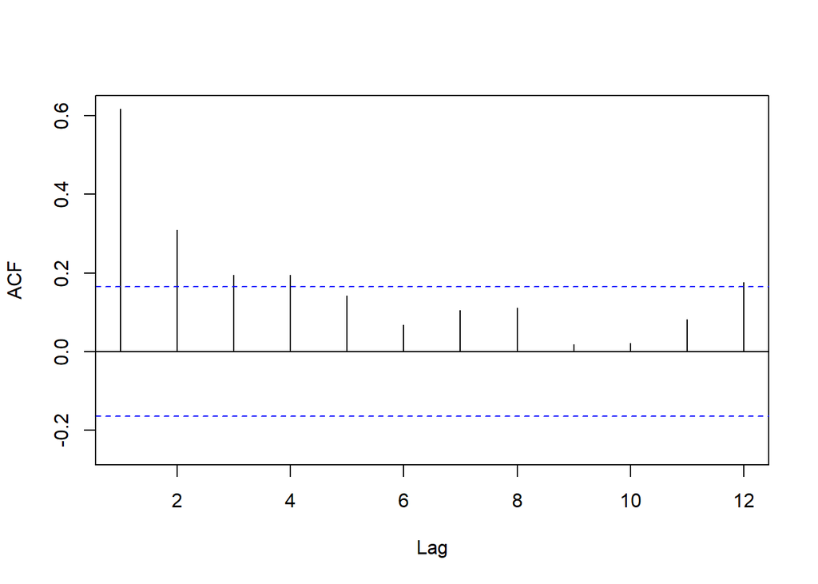

```r
Acf(AirMulti.lm.seasonAndTrend$residuals, lag.max = 12, main="")
```

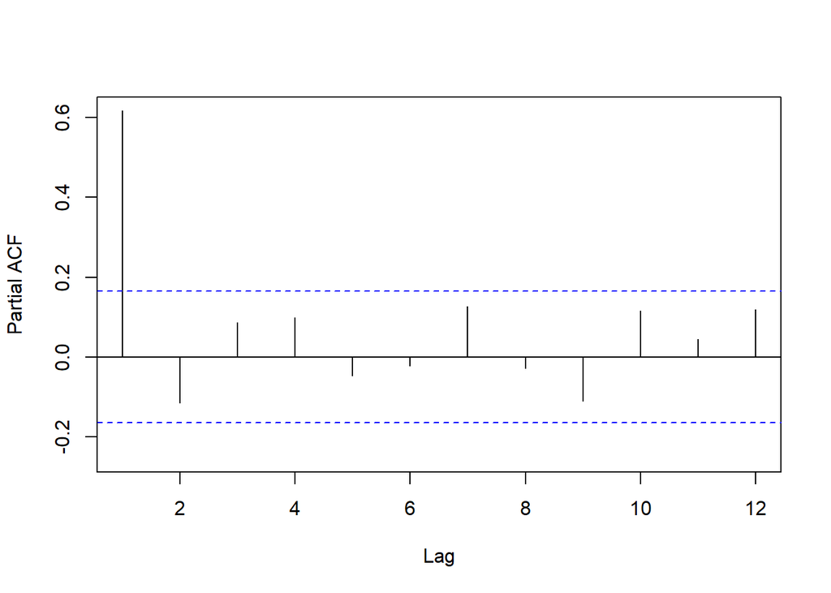

```r
#partial autocorrelation
Pacf(AirMulti.lm.seasonAndTrend$residuals, lag.max = 12, main="")
```

```r
#adding linear trend for Air,rail and Vehicle
# adding linear trend for Air,rail and Vehicle
Air.lm <- tslm(Adjusted_Air_Additive.ts ~ trend)
summary(Air.lm)
```

```
##
## Call:
## tslm(formula = Adjusted_Air_Additive.ts ~ trend)
##
## Residuals:
##      Min       1Q   Median       3Q      Max
## -3792898  -990708  -235321  1036861  4266496
##
## Coefficients:
##             Estimate Std. Error t value Pr(>|t|)
## (Intercept) 35991642     248207  145.01   <2e-16 ***
## trend         172521       3054   56.48   <2e-16 ***
## ---
## Signif. codes:  0 '***' 0.001 '**' 0.01 '*' 0.05 '.' 0.1 ' ' 1
##
## Residual standard error: 1461000 on 138 degrees of freedom
## Multiple R-squared:  0.9585, Adjusted R-squared:  0.9582
## F-statistic:  3190 on 1 and 138 DF,  p-value: < 2.2e-16
```

```r
Rail.lm <- tslm(Adjusted_Rail.ts ~ trend)
summary(Rail.lm)
```

```
##
## Call:
## tslm(formula = Adjusted_Rail.ts ~ trend)
##
## Residuals:
##       Min        1Q    Median        3Q       Max
## -79920032 -16677231   -691451  22938159  67203512
##
## Coefficients:
##              Estimate Std. Error t value Pr(>|t|)
## (Intercept) 551149090    5152924  106.96   <2e-16 ***
## trend         -894795      63411  -14.11   <2e-16 ***
## ---
## Signif. codes:  0 '***' 0.001 '**' 0.01 '*' 0.05 '.' 0.1 ' ' 1
##
## Residual standard error: 30320000 on 138 degrees of freedom
## Multiple R-squared:  0.5906, Adjusted R-squared:  0.5877
## F-statistic: 199.1 on 1 and 138 DF,  p-value: < 2.2e-16
```

```r
Vehicle.lm <- tslm(Adjusted_vehicle.ts ~ trend)
summary(Rail.lm)
```

```
##
## Call:
## tslm(formula = Adjusted_Rail.ts ~ trend)
##
## Residuals:
##       Min        1Q    Median        3Q       Max
## -79920032 -16677231   -691451  22938159  67203512
##
## Coefficients:
##              Estimate Std. Error t value Pr(>|t|)
## (Intercept) 551149090    5152924  106.96   <2e-16 ***
## trend         -894795      63411  -14.11   <2e-16 ***
## ---
## Signif. codes:  0 '***' 0.001 '**' 0.01 '*' 0.05 '.' 0.1 ' ' 1
##
## Residual standard error: 30320000 on 138 degrees of freedom
## Multiple R-squared:  0.5906, Adjusted R-squared:  0.5877
## F-statistic: 199.1 on 1 and 138 DF,  p-value: < 2.2e-16
```

```r
# fitting Quadratic trend for Rail
Rail.lm <- tslm(Adjusted_Rail.ts ~ trend + I(trend^2))
summary(Rail.lm)
```

```
##
## Call:
## tslm(formula = Adjusted_Rail.ts ~ trend + I(trend^2))
##
## Residuals:
##       Min        1Q    Median        3Q       Max
## -79976021 -17195888   3102700  18269778  74233911
##
## Coefficients:
##              Estimate Std. Error t value Pr(>|t|)
## (Intercept) 577839908    7214050  80.099  < 2e-16 ***
## trend        -2022576     236210  -8.563 2.01e-14 ***
## I(trend^2)       7998       1623   4.929 2.35e-06 ***
## ---
## Signif. codes:  0 '***' 0.001 '**' 0.01 '*' 0.05 '.' 0.1 ' ' 1
##
## Residual standard error: 28050000 on 137 degrees of freedom
## Multiple R-squared:  0.6523, Adjusted R-squared:  0.6472
## F-statistic: 128.5 on 2 and 137 DF,  p-value: < 2.2e-16
```

```r
#  generate the naive and seasonal naive forecasts
Airnaive.pred <- forecast::naive(Adjusted_Air_Additive.ts, h = 36)
Airsnaive.pred <- forecast::snaive(Adjusted_Air_Additive.ts, h = 36)
Airnaive.pred
```

```
##          Point Forecast    Lo 80    Hi 80    Lo 95    Hi 95
## Sep 2001       60320858 58740894 61900822 57904511 62737204
## Oct 2001       60320858 58086451 62555264 56903628 63738088
## Nov 2001       60320858 57584280 63057436 56135623 64506093
## Dec 2001       60320858 57160930 63480786 55488165 65153551
## Jan 2002       60320858 56787951 63853765 54917743 65723973
## Feb 2002       60320858 56450752 64190964 54402042 66239674
## Mar 2002       60320858 56140666 64501050 53927806 66713910
## Apr 2002       60320858 55852044 64789671 53486398 67155318
## May 2002       60320858 55580965 65060750 53071818 67569897
## Jun 2002       60320858 55324573 65317143 52679699 67962016
## Jul 2002       60320858 55080710 65561006 52306743 68334973
## Aug 2002       60320858 54847702 65794014 51950388 68691328
## Sep 2002       60320858 54624216 66017499 51608596 69033119
## Oct 2002       60320858 54409173 66232542 51279717 69361999
## Nov 2002       60320858 54201683 66440032 50962388 69679328
## Dec 2002       60320858 54001001 66640714 50655471 69986244
## Jan 2003       60320858 53806499 66835217 50358006 70283710
## Feb 2003       60320858 53617638 67024078 50069167 70572548
## Mar 2003       60320858 53433954 67207762 49788247 70853468
## Apr 2003       60320858 53255043 67386672 49514627 71127088
## May 2003       60320858 53080553 67561163 49247767 71393949
## Jun 2003       60320858 52910169 67731546 48987188 71654528
## Jul 2003       60320858 52743616 67898099 48732467 71909249
## Aug 2003       60320858 52580646 68061069 48483225 72158490
## Sep 2003       60320858 52421037 68220678 48239125 72402591
## Oct 2003       60320858 52264590 68377125 47999859 72641856
## Nov 2003       60320858 52111123 68530592 47765153 72876563
## Dec 2003       60320858 51960474 68681242 47534754 73106962
## Jan 2004       60320858 51812491 68829225 47308433 73333282
## Feb 2004       60320858 51667038 68974677 47085982 73555733
## Mar 2004       60320858 51523990 69117725 46867209 73774506
## Apr 2004       60320858 51383231 69258484 46651937 73989778
## May 2004       60320858 51244655 69397060 46440003 74201712
## Jun 2004       60320858 51108163 69533552 46231257 74410458
## Jul 2004       60320858 50973664 69668051 46025559 74616157
## Aug 2004       60320858 50841073 69800642 45822778 74818937
```

```r
Airsnaive.pred
```

```
##          Point Forecast    Lo 80    Hi 80    Lo 95    Hi 95
## Sep 2001       58042103 54734360 61349846 52983347 63100859
## Oct 2001       58930667 55622924 62238410 53871911 63989423
## Nov 2001       60364548 57056805 63672291 55305792 65423304
## Dec 2001       57913199 54605456 61220942 52854443 62971955
## Jan 2002       58167303 54859560 61475046 53108547 63226059
## Feb 2002       57630989 54323246 60938732 52572233 62689745
## Mar 2002       60906619 57598876 64214362 55847863 65965375
## Apr 2002       60790120 57482377 64097862 55731363 65848876
## May 2002       59870253 56562510 63177996 54811497 64929009
## Jun 2002       60857975 57550232 64165717 55799219 65916731
## Jul 2002       61203405 57895662 64511148 56144649 66262161
## Aug 2002       60320858 57013115 63628601 55262102 65379614
## Sep 2002       58042103 53364248 62719958 50887941 65196264
## Oct 2002       58930667 54252812 63608522 51776506 66084829
## Nov 2002       60364548 55686693 65042403 53210386 67518709
## Dec 2002       57913199 53235344 62591054 50759038 65067361
## Jan 2003       58167303 53489448 62845158 51013141 65321464
## Feb 2003       57630989 52953134 62308844 50476827 64785150
## Mar 2003       60906619 56228764 65584473 53752457 68060780
## Apr 2003       60790120 56112265 65467974 53635958 67944281
## May 2003       59870253 55192398 64548108 52716091 67024414
## Jun 2003       60857975 56180120 65535829 53703813 68012136
## Jul 2003       61203405 56525550 65881260 54049243 68357566
## Aug 2003       60320858 55643003 64998712 53166696 67475019
## Sep 2003       58042103 52312924 63771282 49280080 66804126
## Oct 2003       58930667 53201489 64659846 50168645 67692690
## Nov 2003       60364548 54635369 66093726 51602525 69126570
## Dec 2003       57913199 52184020 63642378 49151176 66675222
## Jan 2004       58167303 52438124 63896482 49405280 66929326
## Feb 2004       57630989 51901810 63360167 48868966 66393011
## Mar 2004       60906619 55177440 66635797 52144596 69668641
## Apr 2004       60790120 55060941 66519298 52028097 69552142
## May 2004       59870253 54141074 65599432 51108230 68632275
## Jun 2004       60857975 55128796 66587153 52095952 69619997
## Jul 2004       61203405 55474226 66932584 52441382 69965428
## Aug 2004       60320858 54591679 66050036 51558835 69082880
```

```r
Railnaive.pred <- forecast::naive(Adjusted_Rail.ts, h = 36)
Railsnaive.pred <- forecast::snaive(Adjusted_Rail.ts, h = 36)
Railnaive.pred
```

```
##          Point Forecast     Lo 80     Hi 80     Lo 95     Hi 95
## Sep 2001      469324248 441611581 497036916 426941381 511707116
## Oct 2001      469324248 430132618 508515878 409385822 529262674
## Nov 2001      469324248 421324500 517323996 395914968 542733528
## Dec 2001      469324248 413898913 524749583 384558513 554089983
## Jan 2002      469324248 407356840 531291657 374553275 564095221
## Feb 2002      469324248 401442353 537206143 365507849 573140648
## Mar 2002      469324248 396003422 542645075 357189721 581458776
## Apr 2002      469324248 390940988 547707509 349447396 589201101
## May 2002      469324248 386186245 552462251 342175645 596472851
## Jun 2002      469324248 381689099 556959398 335297853 603350644
## Jul 2002      469324248 377411728 561236768 328756179 609892318
## Aug 2002      469324248 373324752 565323745 322505688 616142808
## Sep 2002      469324248 369404804 569243692 316510646 622137851
## Oct 2002      469324248 365632941 573015555 310742079 627906418
## Nov 2002      469324248 361993548 576654948 305176108 633472389
## Dec 2002      469324248 358473578 580174918 299792778 638855719
## Jan 2003      469324248 355061993 583586504 294575208 644073288
## Feb 2003      469324248 351749357 586899139 289508970 649139527
## Mar 2003      469324248 348527531 590120966 284581611 654066885
## Apr 2003      469324248 345389431 593259065 279782302 658866194
## May 2003      469324248 342328851 596319645 275101549 663546947
## Jun 2003      469324248 339340315 599308181 270530978 668117518
## Jul 2003      469324248 336418963 602229533 266063156 672585341
## Aug 2003      469324248 333560458 605088038 261691449 676957047
## Sep 2003      469324248 330760910 607887586 257409910 681238586
## Oct 2003      469324248 328016815 610631681 253213179 685435317
## Nov 2003      469324248 325325003 613323493 249096408 689552088
## Dec 2003      469324248 322682595 615965901 245055193 693593303
## Jan 2004      469324248 320086966 618561530 241085521 697562975
## Feb 2004      469324248 317535717 621112780 237183722 701464775
## Mar 2004      469324248 315026645 623621851 233346428 705302068
## Apr 2004      469324248 312557727 626090769 229570543 709077953
## May 2004      469324248 310127093 628521403 225853210 712795286
## Jun 2004      469324248 307733017 630915480 222191786 716456710
## Jul 2004      469324248 305373896 633274600 218583822 720064674
## Aug 2004      469324248 303048243 635600254 215027043 723621454
```

```r
Railsnaive.pred
```

```
##          Point Forecast     Lo 80     Hi 80     Lo 95     Hi 95
## Sep 2001      475278525 431844910 518712139 408852544 541704506
## Oct 2001      475832337 432398722 519265951 409406356 542258318
## Nov 2001      469231164 425797550 512664779 402805183 535657145
## Dec 2001      463218538 419784924 506652153 396792557 529644519
## Jan 2002      447640311 404206696 491073925 381214330 514066292
## Feb 2002      456810210 413376595 500243824 390384228 523236191
## Mar 2002      446471738 403038124 489905353 380045757 512897719
## Apr 2002      454642004 411208389 498075618 388216023 521067985
## May 2002      447509962 404076348 490943577 381083981 513935944
## Jun 2002      494870959 451437345 538304574 428444978 561296940
## Jul 2002      479434174 436000559 522867788 413008193 545860155
## Aug 2002      469324248 425890634 512757863 402898267 535750229
## Sep 2002      475278525 413854118 536702931 381338001 569219048
## Oct 2002      475832337 414407930 537256743 381891813 569772860
## Nov 2002      469231164 407806758 530655571 375290641 563171688
## Dec 2002      463218538 401794131 524642945 369278015 557159062
## Jan 2003      447640311 386215904 509064718 353699788 541580834
## Feb 2003      456810210 395385803 518234616 362869686 550750733
## Mar 2003      446471738 385047331 507896145 352531215 540412262
## Apr 2003      454642004 393217597 516066411 360701481 548582527
## May 2003      447509962 386085556 508934369 353569439 541450486
## Jun 2003      494870959 433446552 556295366 400930436 588811482
## Jul 2003      479434174 418009767 540858581 385493650 573374697
## Aug 2003      469324248 407899842 530748655 375383725 563264772
## Sep 2003      475278525 400049298 550507752 360225351 590331699
## Oct 2003      475832337 400603110 551061564 360779163 590885511
## Nov 2003      469231164 394001937 544460391 354177990 584284339
## Dec 2003      463218538 387989311 538447765 348165364 578271712
## Jan 2004      447640311 372411084 522869538 332587137 562693485
## Feb 2004      456810210 381580983 532039437 341757035 571863384
## Mar 2004      446471738 371242511 521700965 331418564 561524912
## Apr 2004      454642004 379412777 529871231 339588830 569695178
## May 2004      447509962 372280735 522739189 332456788 562563137
## Jun 2004      494870959 419641732 570100186 379817785 609924133
## Jul 2004      479434174 404204947 554663401 364381000 594487348
## Aug 2004      469324248 394095021 544553475 354271074 584377422
```

```r
Vehiclenaive.pred <- forecast::naive(Adjusted_vehicle.ts, h = 36)
Vehiclesnaive.pred <- forecast::snaive(Adjusted_vehicle.ts, h = 36)
Vehiclenaive.pred
```

```
##          Point Forecast    Lo 80    Hi 80    Lo 95    Hi 95
## Sep 2001       232.9562 229.1683 236.7441 227.1631 238.7493
## Oct 2001       232.9562 227.5993 238.3131 224.7635 241.1489
## Nov 2001       232.9562 226.3953 239.5171 222.9222 242.9902
## Dec 2001       232.9562 225.3804 240.5320 221.3700 244.5425
## Jan 2002       232.9562 224.4862 241.4263 220.0024 245.9100
## Feb 2002       232.9562 223.6777 242.2347 218.7660 247.1464
## Mar 2002       232.9562 222.9343 242.9781 217.6290 248.2834
## Apr 2002       232.9562 222.2424 243.6701 216.5708 249.3416
## May 2002       232.9562 221.5924 244.3200 215.5768 250.3356
## Jun 2002       232.9562 220.9778 244.9347 214.6367 251.2757
## Jul 2002       232.9562 220.3931 245.5193 213.7426 252.1698
## Aug 2002       232.9562 219.8345 246.0780 212.8882 253.0242
## Sep 2002       232.9562 219.2987 246.6138 212.0688 253.8436
## Oct 2002       232.9562 218.7831 247.1293 211.2803 254.6321
## Nov 2002       232.9562 218.2857 247.6268 210.5195 255.3929
## Dec 2002       232.9562 217.8045 248.1079 209.7837 256.1287
## Jan 2003       232.9562 217.3382 248.5742 209.0705 256.8419
## Feb 2003       232.9562 216.8854 249.0270 208.3781 257.5344
## Mar 2003       232.9562 216.4450 249.4674 207.7046 258.2079
## Apr 2003       232.9562 216.0161 249.8963 207.0486 258.8638
## May 2003       232.9562 215.5978 250.3146 206.4088 259.5036
## Jun 2003       232.9562 215.1893 250.7231 205.7840 260.1284
## Jul 2003       232.9562 214.7900 251.1224 205.1734 260.7391
## Aug 2003       232.9562 214.3993 251.5132 204.5758 261.3366
## Sep 2003       232.9562 214.0166 251.8958 203.9906 261.9218
## Oct 2003       232.9562 213.6415 252.2709 203.4170 262.4955
## Nov 2003       232.9562 213.2736 252.6388 202.8542 263.0582
## Dec 2003       232.9562 212.9124 253.0000 202.3019 263.6105
## Jan 2004       232.9562 212.5576 253.3548 201.7593 264.1531
## Feb 2004       232.9562 212.2089 253.7035 201.2260 264.6865
## Mar 2004       232.9562 211.8660 254.0465 200.7015 265.2110
## Apr 2004       232.9562 211.5285 254.3839 200.1853 265.7271
## May 2004       232.9562 211.1963 254.7162 199.6772 266.2352
## Jun 2004       232.9562 210.8690 255.0434 199.1768 266.7356
## Jul 2004       232.9562 210.5466 255.3658 198.6836 267.2288
## Aug 2004       232.9562 210.2287 255.6837 198.1975 267.7150
```

```r
Vehiclesnaive.pred
```

```
##          Point Forecast    Lo 80    Hi 80    Lo 95    Hi 95
## Sep 2001       226.7648 219.3464 234.1831 215.4194 238.1101
## Oct 2001       230.4437 223.0254 237.8621 219.0984 241.7891
## Nov 2001       232.0870 224.6686 239.5053 220.7416 243.4323
## Dec 2001       226.5379 219.1196 233.9563 215.1926 237.8833
## Jan 2002       230.0111 222.5928 237.4294 218.6657 241.3565
## Feb 2002       227.7085 220.2901 235.1268 216.3631 239.0538
## Mar 2002       231.5535 224.1352 238.9719 220.2082 242.8989
## Apr 2002       231.9106 224.4923 239.3289 220.5652 243.2560
## May 2002       232.4515 225.0332 239.8699 221.1062 243.7969
## Jun 2002       231.7163 224.2979 239.1346 220.3709 243.0616
## Jul 2002       230.3019 222.8836 237.7203 218.9566 241.6473
## Aug 2002       232.9562 225.5379 240.3745 221.6109 244.3016
## Sep 2002       226.7648 216.2737 237.2559 210.7200 242.8095
## Oct 2002       230.4437 219.9526 240.9348 214.3990 246.4885
## Nov 2002       232.0870 221.5959 242.5781 216.0422 248.1317
## Dec 2002       226.5379 216.0468 237.0290 210.4932 242.5827
## Jan 2003       230.0111 219.5200 240.5022 213.9663 246.0559
## Feb 2003       227.7085 217.2174 238.1996 211.6637 243.7532
## Mar 2003       231.5535 221.0624 242.0446 215.5088 247.5983
## Apr 2003       231.9106 221.4195 242.4017 215.8658 247.9554
## May 2003       232.4515 221.9604 242.9426 216.4068 248.4963
## Jun 2003       231.7163 221.2252 242.2074 215.6715 247.7610
## Jul 2003       230.3019 219.8108 240.7930 214.2572 246.3467
## Aug 2003       232.9562 222.4651 243.4473 216.9114 249.0010
## Sep 2003       226.7648 213.9159 239.6137 207.1140 246.4155
## Oct 2003       230.4437 217.5948 243.2926 210.7930 250.0945
## Nov 2003       232.0870 219.2380 244.9359 212.4362 251.7377
## Dec 2003       226.5379 213.6890 239.3868 206.8872 246.1887
## Jan 2004       230.0111 217.1622 242.8600 210.3604 249.6618
## Feb 2004       227.7085 214.8595 240.5574 208.0577 247.3592
## Mar 2004       231.5535 218.7046 244.4024 211.9028 251.2043
## Apr 2004       231.9106 219.0617 244.7595 212.2599 251.5613
## May 2004       232.4515 219.6026 245.3005 212.8008 252.1023
## Jun 2004       231.7163 218.8673 244.5652 212.0655 251.3670
## Jul 2004       230.3019 217.4530 243.1509 210.6512 249.9527
## Aug 2004       232.9562 220.1073 245.8051 213.3055 252.6069
```